# Simpson’s Paradox

Andy Grogan-Kaylor  
2021-05-18

# Introduction

*Simpson’s Paradox* is the idea that associations between variables that are found between two variables in the sample as a whole, can be *very different* (or even *reversed*) when a third variable is introduced.

There are specific mathematical conditions under which Simpson’s Paradox applies. However, thinking through these mathematical conditions may not be helpful to develop intuitions about Simpson’s Paradox.

Careful inspection of visualizations can help us to develop some understanding of Simpson’s Paradox.

> The key substantive conclusion is that models of the data that only account for two variables may provide *very different*–or even *opposite*–conclusions from models of the world that account for many variables.

# Some Hypothetical Data

These data are based on the hypothetical data provided by Simpson (1951).

| count | treatment | status | group |
| --- | --- | --- | --- |
| 4 | untreated | alive | A |
| 3 | untreated | dead | A |
| 8 | treated | alive | A |
| 5 | treated | dead | A |
| 2 | untreated | alive | B |
| 3 | untreated | dead | B |
| 12 | treated | alive | B |
| 15 | treated | dead | B |

# Sample As A Whole

> The treatment appears to have NO effect. An equal percentage of those receiving and not receiving treatment are alive.

## Cross Tabulation

|  | dead | alive |
| --- | --- | --- |
| **untreated** | 6 | 6 |
| **treated** | 20 | 20 |

## Mosaic Plot

> Mosaic Plots are a little bit counterintuive at first. However, I believe that–after a little bit of study–Mosaic Plots provide the best visual representation of these relationships.

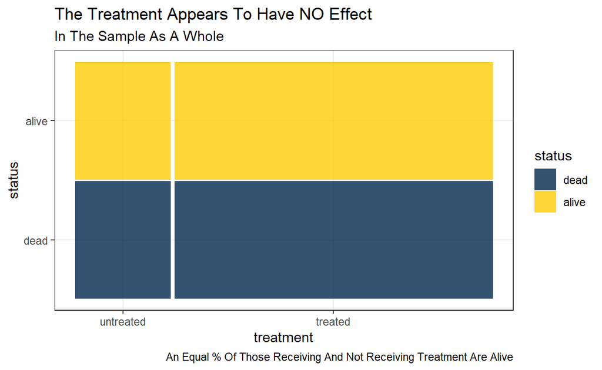

## Pie Chart

> A Pie Chart sometimes is more intuitive at first, but actually has less information than a Mosaic Chart.

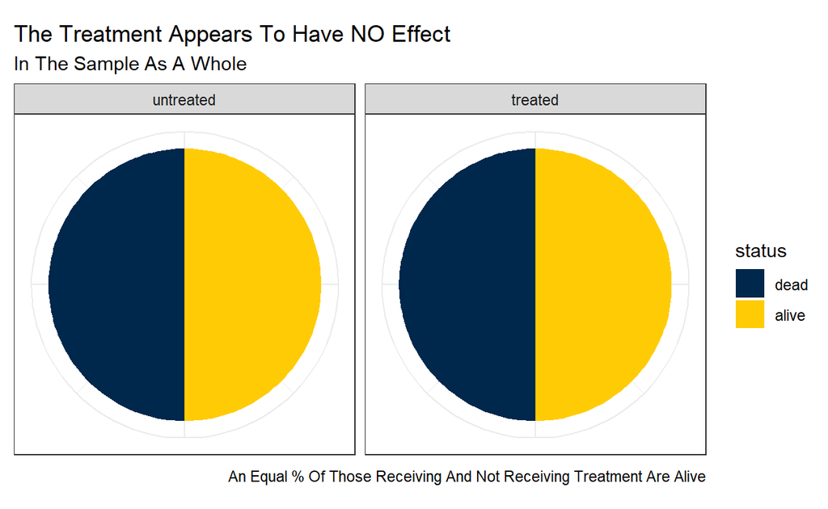

# Sample Divided By Groups

> The treatment appears to have an effect. A greater percentage of those recieving treatment are alive.

## Cross Tabulation

|  |  |  | A | B |
| --- | --- | --- | --- | --- |
| untreated | dead |  | 3 | 3 |
|  | alive |  | 4 | 2 |
| treated | dead |  | 5 | 15 |
|  | alive |  | 8 | 12 |

## Mosaic Plot

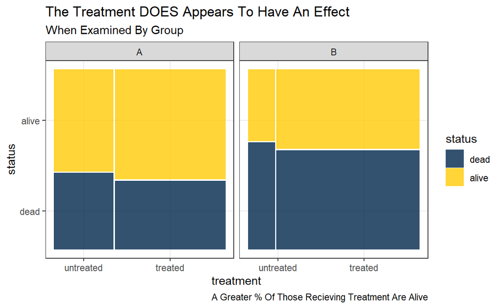

## Pie Chart

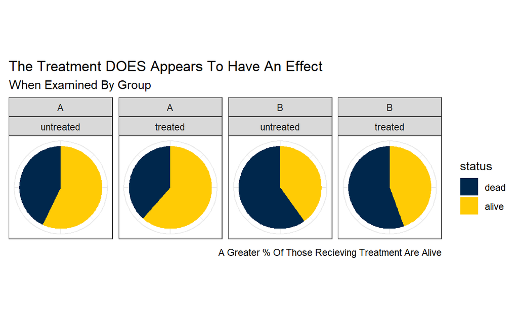

# Reference

Simpson, E. (1951). The Interpretation of Interaction in Contingency Tables. *Journal of the Royal Statistical Society. Series B (Methodological)*, 13(2), 238-241. Retrieved February 2, 2021, from http://www.jstor.org/stable/2984065